# Анализ трафика в Wireshark

Лабораторная работа №3

Гафоров Нурмухаммад

Российский университет дружбы народов, Москва, Россия

9 октября 2025

# Цели и задачи работы

## Цель лабораторной работы

Изучить принципы работы сетевых протоколов ARP, ICMP, TCP, UDP и QUIC посредством анализа трафика в программе **Wireshark**.

# Ход выполнения

## Определение сетевых параметров

На локальном компьютере с помощью команды `ipconfig` были определены IP-адрес, маска подсети и шлюз по умолчанию.

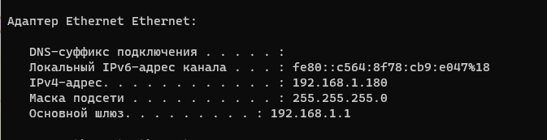

Определение IP-адреса и шлюза по умолчанию

## Проверка доступности шлюза

Был выполнен тест связи командой `ping 192.168.1.1`. Пакеты получены без потерь, что подтвердило корректную работу сети.

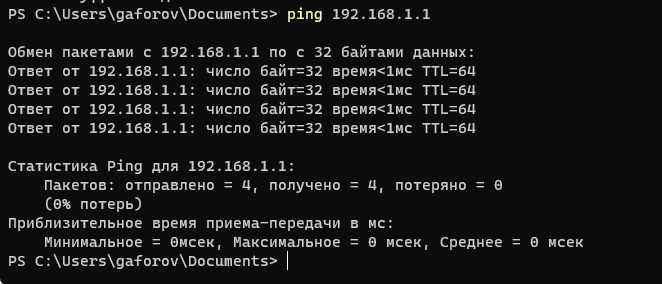

Проверка доступности шлюза

## Анализ ICMP-трафика

В Wireshark применён фильтр `arp or icmp`. Зафиксированы пакеты ICMP Echo Request и Echo Reply между устройством и шлюзом.

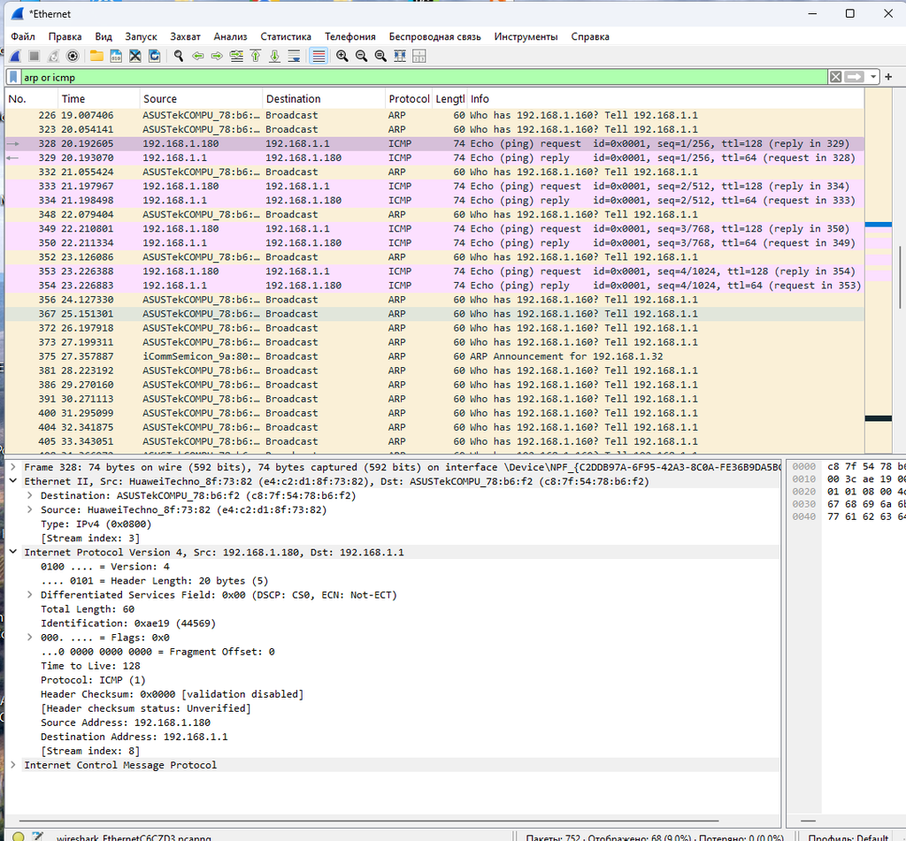

ICMP Echo Request к шлюзу

## Анализ ICMP-трафика

В Wireshark применён фильтр `arp or icmp`. Зафиксированы пакеты ICMP Echo Request и Echo Reply между устройством и шлюзом.

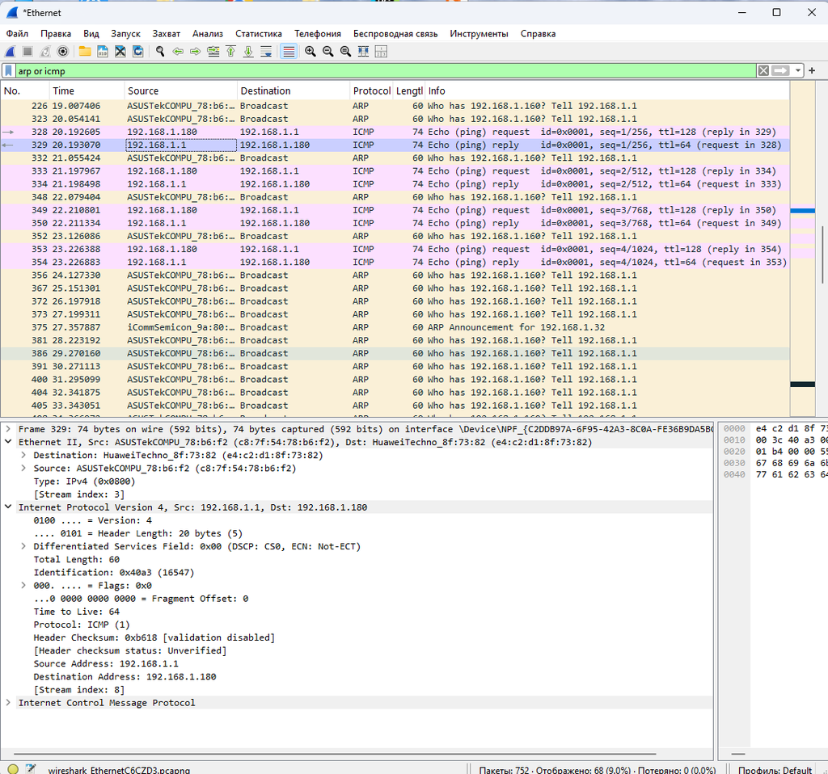

ICMP Echo Reply от шлюза

## Анализ ARP-протокола

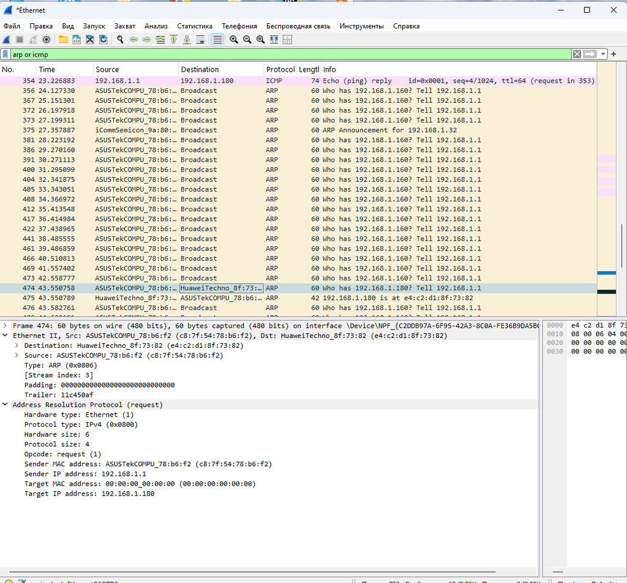

Анализ ARP-запроса

## Проверка связи с внешним ресурсом

Командой `ping yandex.ru` выполнен тест соединения с удалённым узлом. Среднее время отклика составило 8 мс.

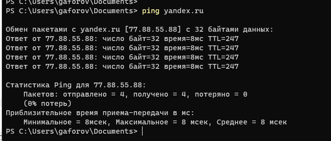

Проверка доступности внешнего ресурса

## Анализ ICMP при обращении к внешнему серверу

Фильтр `arp or icmp` показал обмен ICMP-запросами с адресом **77.88.55.88 (yandex.ru)**.

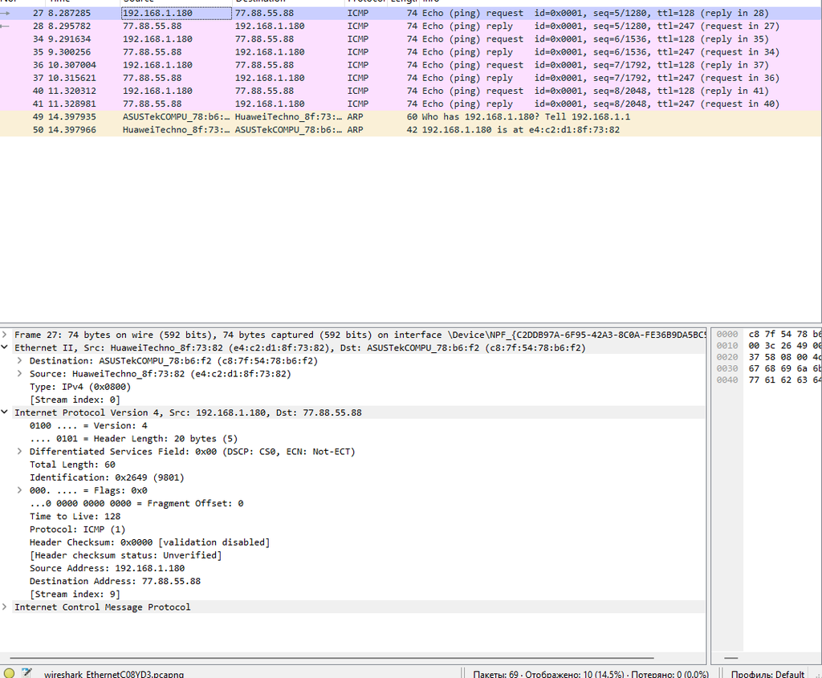

ICMP Echo Request к yandex.ru

## Анализ HTTP и TCP

При фильтрации по `http` зафиксированы запросы **GET** и ответы **HTTP/1.1 304 Not Modified**. Данные передаются через TCP с портом 80.

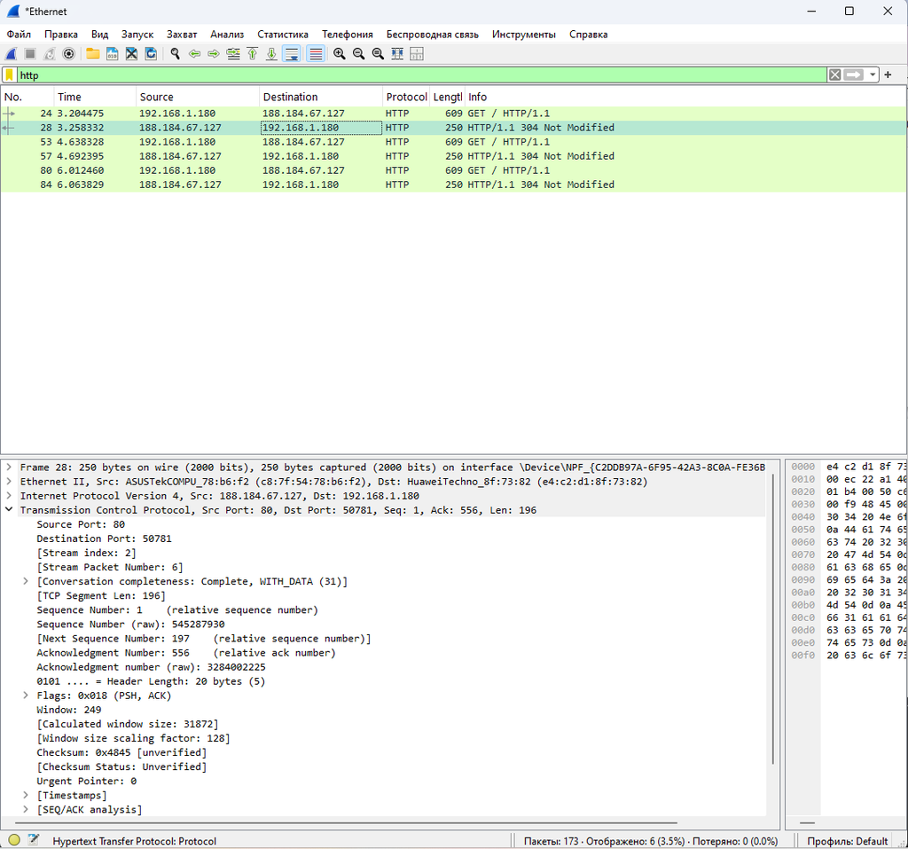

## Анализ DNS и UDP

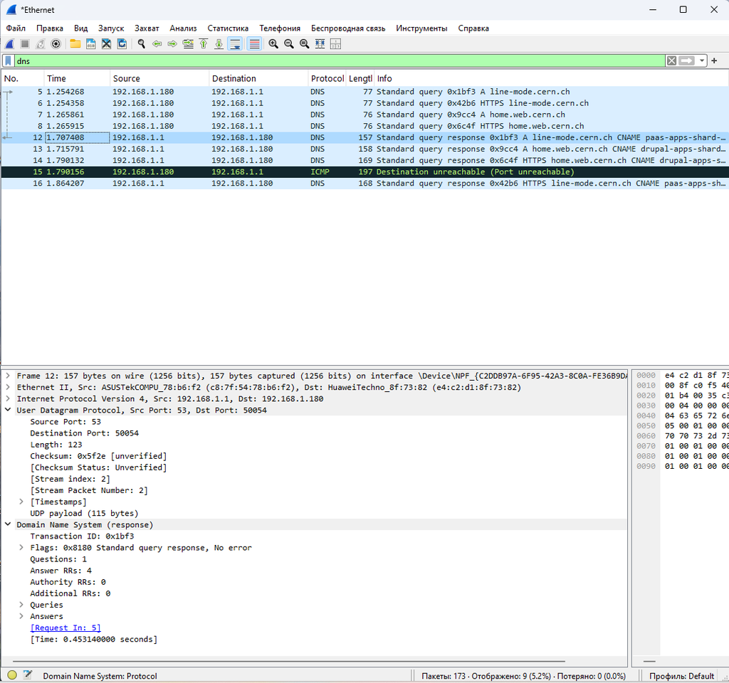

DNS-запросы в Wireshark

## Анализ протокола QUIC

Фильтр `quic` выявил пакеты **Initial**, **Handshake**, **PING** и **CRYPTO**, передаваемые по UDP. Протокол обеспечивает быструю и защищённую передачу данных.

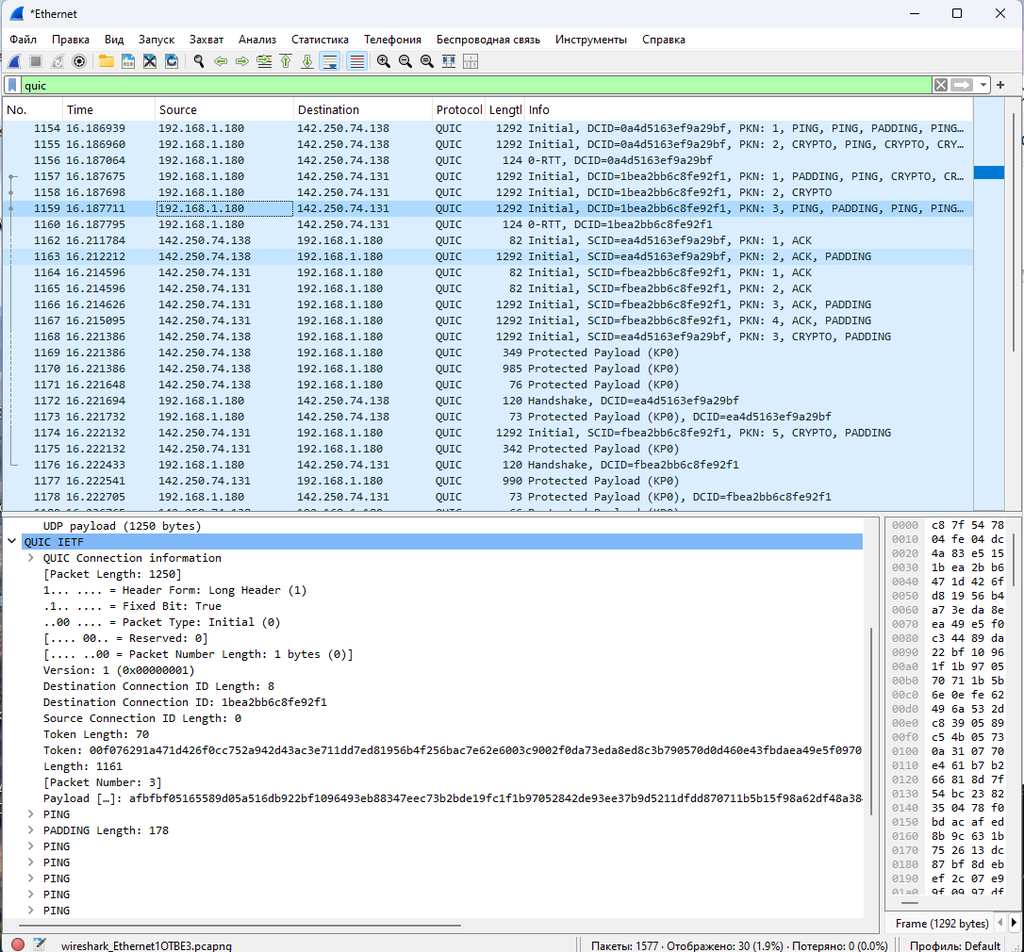

Передача пакетов QUIC в Wireshark

## Анализ handshake TCP

Исследован процесс установления TCP-соединения (**Three-Way Handshake**):  
1. SYN — инициация соединения клиентом.  
2. SYN/ACK — подтверждение сервером.  
3. ACK — завершение установления.

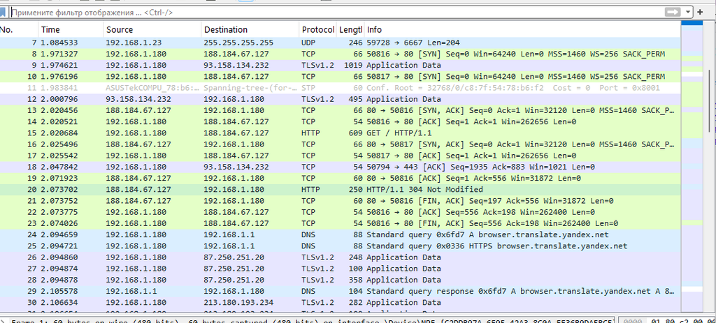

Захват TCP handshake в Wireshark

## График потока TCP

На графике потока отображается последовательность обмена сегментами SYN → SYN/ACK → ACK, подтверждающая корректное установление соединения.

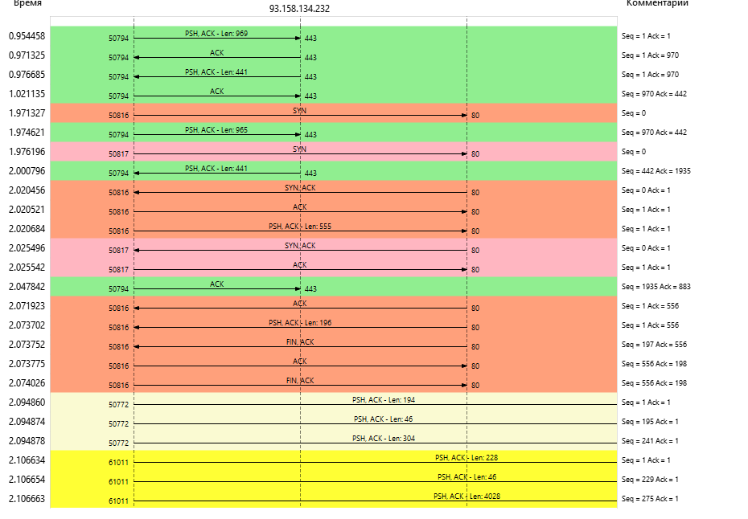

График потока

# Выводы

## Итог лабораторной работы

В результате работы были исследованы протоколы **ARP**, **ICMP**, **TCP**, **UDP** и **QUIC** с помощью анализатора **Wireshark**.  
Получены практические навыки по анализу сетевого трафика и пониманию принципов работы транспортного уровня стека TCP/IP.

Процесс трёхэтапного установления соединения (**TCP Handshake**) был подробно изучен, что подтвердило надёжность и согласованность протокола TCP.